# Chapter 4

shinya suzuki

2016年11月22日

# Chapter4 GLMのモデル選択-AICとモデルの予測の良さ-

> 欲しいのは「あてはまりが良い」モデルではなく, 「予測が良い」モデルである

## 4.2 あてはまりの悪さ「逸脱度」

次式で定義されている. 最大対数尤度の-2倍である.

$$D = -2 \log L^*$$

ここで様々なパターンの逸脱度を定義しておこう.

- 逸脱度($D$)
  - $-2 \log L^*$
- 最小の逸脱度
  - フルモデルをあてはめたときの逸脱度
- 残差逸脱度
  - $D$-最小の逸脱度
- 最大の逸脱度
  - NULLモデルを当てはめたときのD
- NULL逸脱度
  - 最大の逸脱度-最小の逸脱度
  - NULLモデルのときの残差逸脱度

## なぜAICでモデル選択をしてよいか

モデル選択は次式のAICでおこなわれる. $k$はパラメータ数である.

$$AIC = - 2 \log L^* + 2 k$$

AICによるモデル選択がなぜ有効なのかを理解するには 次の２つを考える必要がある.

- `平均対数尤度`
- 最大対数尤度の`バイアス補正`

観測データに対して最も当てはまりが良くなるが最尤パラメータである. では, 最尤パラメータの**予測の良さ**を知る方法はないのか? ここでは「予測の良さ」を観測データがまた取得できたとして, どの程度の尤度になるのかで測る. そして, いくつもえた尤度の平均値が`平均対数尤度`となる.

平均対数尤度を次式で書く.

$$E(\log L) = \log L^* -b$$

## 平均対数尤度と最大対数尤度の差

それでは前述のものをシミュレーションで確認してみる. モデルは次のNULLモデルを考える.

$$y \tilde \\Poisson(\lambda) \\
\log \lambda = \beta$$

```r
## ポアソン回帰のNULLのモデルで試す
## 最大対数尤度と平均対数尤度のバイアス
generate_sample <- (function() {
    NSIZE  <- 50   # 観測データのサイズ
    LAMBDA <- 8    # パラメータの真の値
    function () {
        rpois(NSIZE, lambda = LAMBDA)
    }
})()
poisson_loglik <- function(y, lambda) {
    sum (dpois(y, lambda, log=TRUE))
}
NTRIAL <- 200
a_sim  <- function (dummy) {
    sample_y    <- generate_sample()
    poisson_fit <- glm (y ~ 1, data=data_frame(y = sample_y), family=poisson)
    maxloglik   <- logLik(poisson_fit)
    ml_beta     <- coef(poisson_fit)
    logliks     <-
        lapply (1:NTRIAL, function(i, lambda) {
            poisson_loglik (
                generate_sample(),
                lambda
            )
        }, lambda = exp (ml_beta)) %>%
        flatten_dbl
    meanloglik <- logliks %>% mean
    return (
        tibble (
            beta       = ml_beta,
            maxloglik  = maxloglik,
            logliks    = list(logliks),
            meanloglik = meanloglik
        )
    )
}
NSIM <- 10
res  <-
    lapply (1:NSIM, a_sim) %>%
    bind_rows()
```

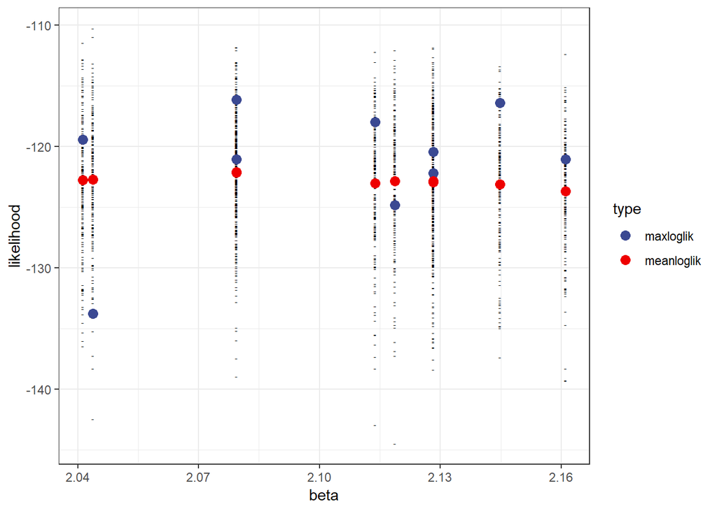

```r
graph_base <-
    res %>%
    dplyr::select (beta, logliks) %>%
    unnest %>%
    ggplot(aes(beta, logliks)) +
    geom_point(shape=45) +
    theme_bw() +
    ylab ("likelihood")
stat_point <-
    res %>%
    dplyr::select (beta, maxloglik, meanloglik) %>%
    gather (type, value, -beta)
graph_base +
    geom_point (data = stat_point, aes(beta,value, colour=type), size=3) +
    scale_color_aaas() +
    theme_bw() +
    ylab ("likelihood")
```

## 平均対数尤度と最大対数尤度の差の分布は?

パラメータ数を平均値として分布している.

```r
## ポアソン回帰のNULLのモデルで試す
## 最大対数尤度と平均対数尤度のバイアス
generate_sample <- (function() {
    NSIZE  <- 50   # 観測データのサイズ
    LAMBDA <- 8    # パラメータの真の値
    function () {
        rpois(NSIZE, lambda = LAMBDA)
    }
})()
poisson_loglik <- function(y, lambda) {
    sum (dpois(y, lambda, log=TRUE))
}
NTRIAL <- 200
a_sim  <- function (dummy) {
    sample_y    <- generate_sample()
    poisson_fit <- glm (y ~ 1, data=data_frame(y = sample_y), family=poisson)
    maxloglik   <- logLik(poisson_fit) %>% as.numeric
    ml_beta     <- coef(poisson_fit)
    meanloglik  <-
        lapply (1:NTRIAL, function(i, lambda) {
            poisson_loglik (
                generate_sample(),
                lambda
            )
        }, lambda = exp (ml_beta)) %>%
        flatten_dbl %>%
        mean
    return (maxloglik-meanloglik)
}
NSIM  <- 300
res   <-
    lapply (1:NSIM, a_sim) %>%
    flatten_dbl
summary (res)
```

```
##     Min.  1st Qu.   Median     Mean  3rd Qu.     Max.
## -18.2627  -2.9660   1.1058   0.7734   4.6655  13.2645
```

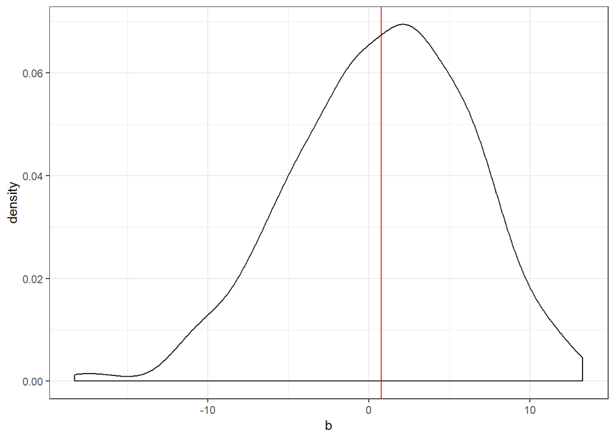

```r
bias  <- data_frame (b = res)
bias %>%
    ggplot (aes(b)) +
    geom_density() +
    theme_bw() +
    geom_vline(xintercept = mean(bias$b), colour="red")
```

## ネストしている場合のAICの比較

ネストしている場合のモデル式を比較することで, 無意味な説明変数が追加された場合にAIC, つまり最大対数尤度と平均対数尤度がどのような挙動を示し, それがパラメータとどのような関係があるかを考える.

結果としては, 応答変数と無関係な 説明変数を追加することで最大対数尤度が0.5上昇するが 平均対数尤度が0.5低下する. つまり, パラメータ数だけ上昇する.

グラフを見ると最大対数尤度は向上しているのがわかるが, 平均対数尤度が低下していることがわかる.

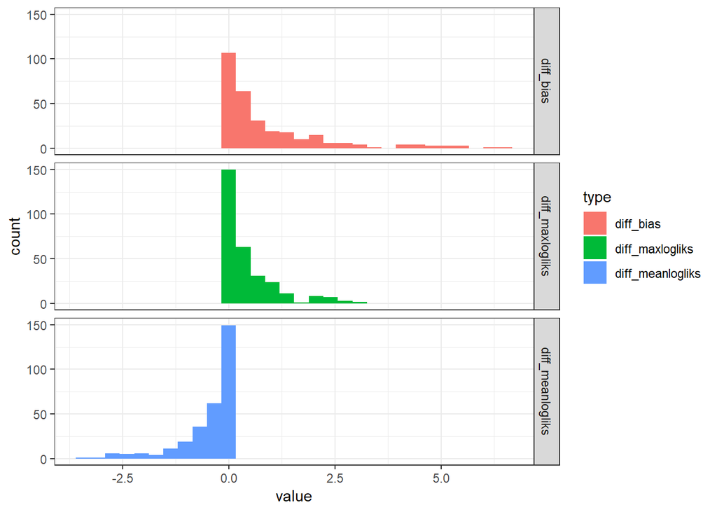

```r
NSIZE  <- 50
LAMBDA <- 8
generate_sample <- (function() {
    function () {
        rpois(NSIZE, lambda = LAMBDA)
    }
})()
poisson_loglik <- function(y, lambda) {
    sum (dpois(y, lambda, log=TRUE))
}
NTRIAL   <- 200
random_x <- rnorm(NSIZE)
a_sim  <- function (dummy) {
    obs <- data_frame (
        y = generate_sample(),
        x = random_x
    )
    fits <-
        list (
            "fix" = "y ~ 1",
            "x"   = "y ~ x"
        ) %>%
        lapply (function(f) {
            glm (f, data = obs, family=poisson)
        })
    maxlogliks <- lapply (fits, function(x) as.numeric(logLik(x)))
    lambda     <-
        fits %>%
        lapply (augment) %>%
        lapply (function(x) {
            exp (x$.fitted)
        })
    meanlogliks <-
        lapply (1:NTRIAL, function(i, lambda) {
            y <- generate_sample()
            c (
                'fix' = poisson_loglik (y, lambda$fix),
                'x'   = poisson_loglik (y, lambda$x)
            )
        }, lambda) %>%
        transpose() %>%
        lapply (flatten_dbl) %>%
        lapply (mean)

    data_frame (
        diff_maxlogliks  = maxlogliks$x  - maxlogliks$fix,
        diff_meanlogliks = meanlogliks$x - meanlogliks$fix,
        diff_bias        =
            c(maxlogliks$x-meanlogliks$x) - c(maxlogliks$fix-meanlogliks$fix)
    )
}
NSIM <- 300
res  <-
    lapply (1:NSIM, a_sim) %>%
    bind_rows()
res %>%
    gather (type, value) %>%
    ggplot(aes(value)) +
    geom_histogram(aes(fill=type)) +
    scale_color_aaas() +
    facet_grid(type ~ .) +
    theme_bw()
```